# Practical Machine Learning

DataMx

February 14, 2015

## Overview

This is the course project write-up for Coursera’s Practical Machine Learning by John Hopkins University. The purpose of this class project was to take Weight Lifting Exercise Dataset from this source: http://groupware.les.inf.puc-rio.br/har.see, use it to build a model with cross validation that could then predict “how well the exercise was done” and describe the choices we made in model selection and the error our model contains.

## Data

Data was collected from 6 participants performing 5 sets of 10 dumbbell curls while wearing accelerometers, gyroscopes and magnetometers on the belt, forearm, arm, and dumbbells. One set per participant was performed correctly, the others had different mistakes in form. The [paper](http://groupware.les.inf.puc-rio.br/public/papers/2013.Velloso.QAR-WLE.pdf) associated with the data is available.

## Reading and Cleaning data

After downloading the data from the course website, the first step was to look at the data to assess what predictors were available. From reading the accompanying [paper](http://groupware.les.inf.puc-rio.br/public/papers/2013.Velloso.QAR-WLE.pdf) and browsing the data, it required some cleaning. The training dataset contains direct measurements and calculated measurements from time slices of the data. The test set does not have the calculated data nor enough data to calculate the missing data. So, all columns in the test set with NAs were removed. The training data was then subsetted to have the same columns except problem_id replaced classe. The index(X), user-name, timestamp and window variables were also removed as they are not quality predictors for dumbbell curls.

```r
#Read Dowloaded files. Treat blanks and NAs as NA and string as factors
pmltrain <- read.csv("~/Documents/Coursera_Data/PracticalMachineLearning/pml-training.csv",
                    na.strings= c("NA", ""))
pmltest <- read.csv("~/Documents/Coursera_Data/PracticalMachineLearning/pml-testing.csv",
                    na.strings="NA")
dim(pmltrain)
```

```
## [1] 19622   160
```

```r
dim(pmltest)
```

```
## [1]  20 160
```

```r
#str(pmltrain) # used to investigate column types
#str(pmltest)
testnona <- pmltest[ , colSums(is.na(pmltest)) == 0] #remove columns with blanks and NAs
trainnona <- pmltrain[ , colSums(is.na(pmltrain)) == 0]
trainnona <- trainnona[,8:60] # remove X, user_name, time and window variables
testnona <- testnona[,8:60]
dim(trainnona)
```

```
## [1] 19622    53
```

```r
dim(testnona)
```

```
## [1] 20 53
```

## Machine Learning Model Prediction Choice

After looking at the data, it seemed as using Random Forest machine learning algorithm could be useful as there are multiple predictors. Also, I do not have a good feel for which predictors or combination of predictors would be most useful and the predictors are a poor fit for a linear regression model without additional steps or information.  
Using `rf` method in the `caret` package took excessive computing time, so I switched to using the ‘randomForest’ package directly. The training data was partitioned into training and cross validation data. I used `tuneRF` to investigate the best value for `mtry`. The default for classification is sqrt(p), where p is the number of predictors being tested, in this case 7. `Mtry` appears to be optimized for this problem. I also tested using k-fold (k = 5) cross validation on the number of model predictors. For the purposes of this project, I decided to use all predictors even though it was more costly in computationally. The model parameters could be cut in halves or quarters and still have greater then 99% accuracy. Using less model parameters, would be beneficial if there appeared to be overfitting.

```r
library (caret)
library (randomForest)
library (knitr)
set.seed(61420) # for reproducibility

#Create 80/20 training/validation set
InTrain<-createDataPartition(y=trainnona$classe, p=0.8,list=FALSE)
trainnona1<-trainnona[InTrain,]
validatenona2<-trainnona[-InTrain,]

#Investigate best value for mtry
tuneRF(trainnona1[,1:52], ntreeTry = 500, trainnona1$classe)
```

```
## mtry = 7  OOB error = 0.39%
## Searching left ...
## mtry = 4     OOB error = 0.51%
## -0.2903226 0.05
## Searching right ...
## mtry = 14    OOB error = 0.41%
## -0.03225806 0.05
```

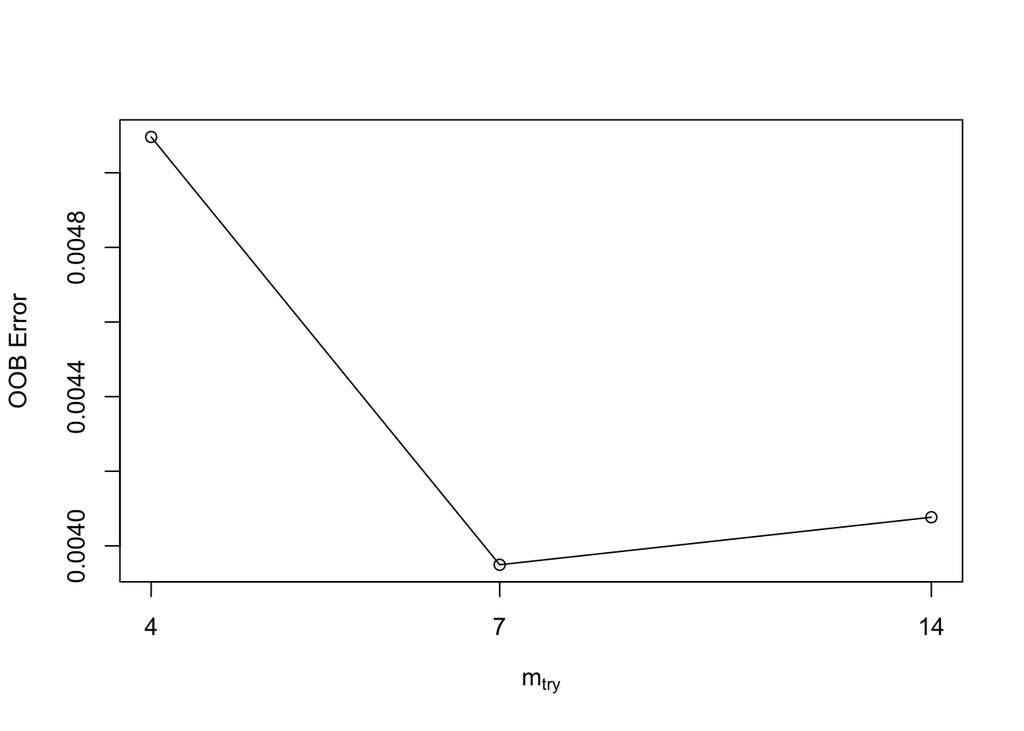

```
##        mtry    OOBError
## 4.OOB     4 0.005095866
## 7.OOB     7 0.003949296
## 14.OOB   14 0.004076693
```

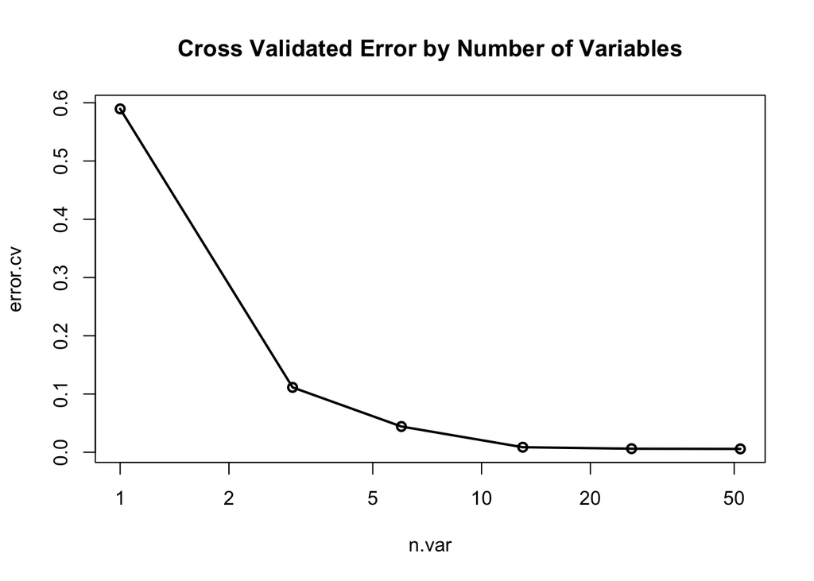

```r
#Use k-fold cross validation (k=5) to investigate reducing number of predictors
rfcv1 <- rfcv(trainnona1[,1:52], trainnona1$classe,  cv.fold = 5, data = trainnona1)
with(rfcv1, plot(n.var, error.cv, log="x", type="o", lwd=2, main = "Cross Validated Error by Number of Variables"))
```

```r
#RandomForest with defaults for mtry and all predictors
rf1 <- randomForest(trainnona1$classe ~ ., data = trainnona1, proximity = TRUE,
                    importance = TRUE)
rf1
```

```
##
## Call:
##  randomForest(formula = trainnona1$classe ~ ., data = trainnona1,      proximity = TRUE, importance = TRUE)
##                Type of random forest: classification
##                      Number of trees: 500
## No. of variables tried at each split: 7
##
##         OOB estimate of  error rate: 0.38%
## Confusion matrix:
##      A    B    C    D    E  class.error
## A 4463    1    0    0    0 0.0002240143
## B   16 3018    4    0    0 0.0065832785
## C    0   11 2725    2    0 0.0047479912
## D    0    0   16 2554    3 0.0073843762
## E    0    0    3    4 2879 0.0024255024
```

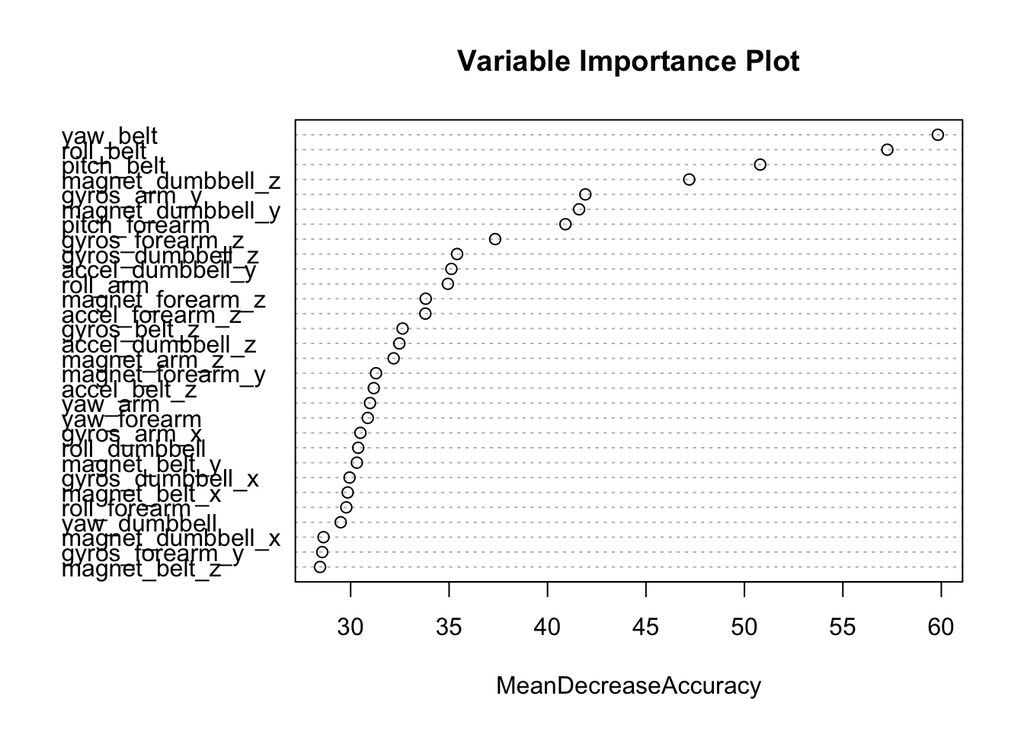

```r
varImpPlot(rf1, type = 1, main = "Variable Importance Plot")
```

```r
kable(rf1$confusion, digits = 4, caption = "Confusion Matrix from Random Forest Training Set")
```

Confusion Matrix from Random Forest Training Set

|  | A | B | C | D | E | class.error |
| --- | --- | --- | --- | --- | --- | --- |
| A | 4463 | 1 | 0 | 0 | 0 | 0.0002 |
| B | 16 | 3018 | 4 | 0 | 0 | 0.0066 |
| C | 0 | 11 | 2725 | 2 | 0 | 0.0047 |
| D | 0 | 0 | 16 | 2554 | 3 | 0.0074 |
| E | 0 | 0 | 3 | 4 | 2879 | 0.0024 |

```r
oob <-1 - (rf1$confusion[1,1]+rf1$confusion[2,2]+rf1$confusion[3,3]+rf1$confusion[4,4]+rf1$confusion[5,5])/sum(rf1$confusion[,1:5])
```

The varImpPlot shows which predictors (maxed out at 30 displayed) are contributing the most to the model.

### Validation

```r
library (knitr)
prediction1 <- predict(rf1, validatenona2)
kable(table(prediction1,validatenona2$classe), digits = 2, caption = "Confusion Matrix from Validation Set")
```

Confusion Matrix from Validation Set

|  | A | B | C | D | E |
| --- | --- | --- | --- | --- | --- |
| A | 1116 | 0 | 0 | 0 | 0 |
| B | 0 | 757 | 3 | 0 | 0 |
| C | 0 | 2 | 681 | 6 | 1 |
| D | 0 | 0 | 0 | 637 | 2 |
| E | 0 | 0 | 0 | 0 | 718 |

```r
accuracy <- sum(prediction1==validatenona2$classe)/length(validatenona2$classe)
```

This validation gives us an accuracy of **0.9964**. and out of sample error rate of **0.36%**. Random Forest OOB estimates of error rate are considered unbiased and was calculated at **0.38%** showing us why random forest is not typically run with extra cross validation. It is possible to overfit the data to model but as the training and validation have similar error rates, it is unlikely the model is overfit in this case.  
One of the ways to decrease overfitting is to use fewer parameters, so using the `rfcv` function could helps us determine how many parameters to use.

From the results of the cross validation, I feel like this particular Random Forest model should do a good job of fitting the test data.

## Prediction of Test Values

```r
answers <- predict(rf1, testnona)
```

I then convert the predictions into individual files for submission on the course webpage.

## Submission of Predictions

Function to convert test set predictions to individual files for submission.

```r
pml_write_files = function(x){
  n = length(x)
  for(i in 1:n){
    filename = paste0("problem_id_",i,".txt")
    write.table(x[i],file=filename,quote=FALSE,row.names=FALSE,col.names=FALSE)
  }
}
pml_write_files(as.character(answers))
```

Twenty out of twenty predictions were correct.

#### License for Data

Important: you are free to use this dataset for any purpose. This dataset is licensed under the Creative Commons license (CC BY-SA). The CC BY-SA license means you can remix, tweak, and build upon this work even for commercial purposes, as long as you credit the authors of the original work and you license your new creations under the identical terms we are licensing to you. This license is often compared to “copyleft” free and open source software licenses. All new works based on this dataset will carry the same license, so any derivatives will also allow commercial use. Read more: http://groupware.les.inf.puc-rio.br/har#ixzz3RiwCo6Bl

#### Paper reference

Velloso, E.; Bulling, A.; Gellersen, H.; Ugulino, W.; Fuks, H. Qualitative Activity Recognition of Weight Lifting Exercises. Proceedings of 4th International Conference in Cooperation with SIGCHI (Augmented Human ’13) . Stuttgart, Germany: ACM SIGCHI, 2013.

This html file can be found at http://datamx.github.io/PracticalMachineLearning/pml.html